# HR Attrition

# Introduction:

In this notebook I will be looking at IBM’s employee attrition data obtained from Kaggle https://www.kaggle.com/pavansubhasht/ibm-hr-analytics-attrition-dataset

```r
library(tidyverse)
library(caret)
library(DataExplorer)
setwd("~/HRattrition")
df = read.csv("WA_Fn-UseC_-HR-Employee-Attrition 2.csv")
df$Over18 = NULL
df$EmployeeCount = NULL
df$StandardHours = NULL
```

# EDA

```r
#taking a quick look at the data
df %>% head()
```

|  | Age | Attrition | BusinessTravel | DailyRate | Department | DistanceFromHome | Education | EducationField | EmployeeNumber | EnvironmentSatisfaction | Gender | HourlyRate | JobInvolvement | JobLevel | JobRole | JobSatisfaction | MaritalStatus | MonthlyIncome | MonthlyRate | NumCompaniesWorked | OverTime | PercentSalaryHike | PerformanceRating | RelationshipSatisfaction | StockOptionLevel | TotalWorkingYears | TrainingTimesLastYear | WorkLifeBalance | YearsAtCompany | … |
| --- | --- | --- | --- | --- | --- | --- | --- | --- | --- | --- | --- | --- | --- | --- | --- | --- | --- | --- | --- | --- | --- | --- | --- | --- | --- | --- | --- | --- | --- | --- |
| 1 | 41 | Yes | Travel_Rarely | 1102 | Sales | 1 | 2 | Life Sciences | 1 | 2 | Female | 94 | 3 | 2 | Sales Executive | 4 | Single | 5993 | 19479 | 8 | Yes | 11 | 3 | 1 | 0 | 8 | 0 | 1 | 6 | … |
| 2 | 49 | No | Travel_Frequently | 279 | Research & Development | 8 | 1 | Life Sciences | 2 | 3 | Male | 61 | 2 | 2 | Research Scientist | 2 | Married | 5130 | 24907 | 1 | No | 23 | 4 | 4 | 1 | 10 | 3 | 3 | 10 | … |
| 3 | 37 | Yes | Travel_Rarely | 1373 | Research & Development | 2 | 2 | Other | 4 | 4 | Male | 92 | 2 | 1 | Laboratory Technician | 3 | Single | 2090 | 2396 | 6 | Yes | 15 | 3 | 2 | 0 | 7 | 3 | 3 | 0 | … |
| 4 | 33 | No | Travel_Frequently | 1392 | Research & Development | 3 | 4 | Life Sciences | 5 | 4 | Female | 56 | 3 | 1 | Research Scientist | 3 | Married | 2909 | 23159 | 1 | Yes | 11 | 3 | 3 | 0 | 8 | 3 | 3 | 8 | … |
| 5 | 27 | No | Travel_Rarely | 591 | Research & Development | 2 | 1 | Medical | 7 | 1 | Male | 40 | 3 | 1 | Laboratory Technician | 2 | Married | 3468 | 16632 | 9 | No | 12 | 3 | 4 | 1 | 6 | 3 | 3 | 2 | … |
| 6 | 32 | No | Travel_Frequently | 1005 | Research & Development | 2 | 2 | Life Sciences | 8 | 4 | Male | 79 | 3 | 1 | Laboratory Technician | 4 | Single | 3068 | 11864 | 0 | No | 13 | 3 | 3 | 0 | 8 | 2 | 2 | 7 | … |

The plot_histogram() function from DataExplorer is useful to plot the distributions of all numeric values in a dataframe. One thing to note is that Age is the only variable that is nearing normality.

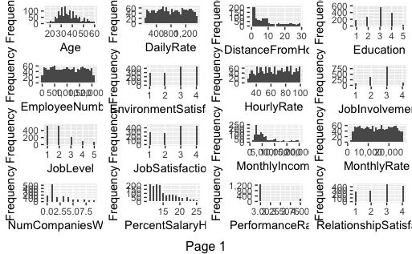

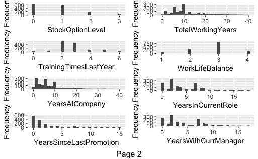

```r
df %>% plot_histogram()
```

There is no missing values in the whole dataset. This is helpful because missing values are problematic when modeling.

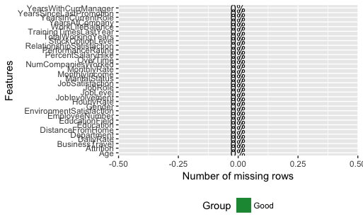

```r
df %>% plot_missing()
```

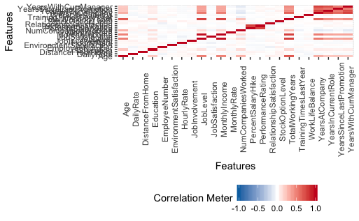

```r
df %>% select_if(is.numeric) %>%  plot_correlation(type = "c")
```

The varible of interest for prediction is *Attrition* a 2 level factor that indicated whether turnover occured with the given observation. I plot a simple barplot of the Attrition variable.

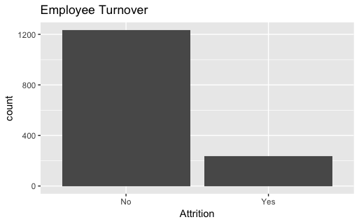

```r
df %>% ggplot(aes(Attrition)) +
  geom_bar()+
  ggtitle("Employee Turnover")
```

# Modeling

The first model that I will fit is a random forest model using the randomForest package. Random forests are my favorite model. They are quite accurate and provide alot of important information about the relationship between the response variable and the predictors.

```r
# I import the caret library which I will use throughout this analysis
library(caret)
# I define a 70 - 30 train test split in the data.
split = createDataPartition(df$Attrition, p = 0.7, list = F)
train = df[split,]
test = df[-split,]
```

The Random forest model is fairly accurate on the held out test set. It is noteable that specificity is quite low in the model. This hihglights the fact the model is having a difficult time distinguishing between true and false negatives. This moodel does not do the best at predicting employees that do actually end up leaving the company.

```r
library(randomForest)
# I fit a random forest using the default parameters
rf =randomForest::randomForest(Attrition~., data = train)
pred = predict(rf, test, type = "response")
#pred[pred > 0.5] = "Yes"
#pred[pred < 0.5] = "No"
mean(pred == test$Attrition)
```

```
[1] 0.8636364
```

```r
confusionMatrix(pred, test$Attrition)
```

```
Confusion Matrix and Statistics

          Reference
Prediction  No Yes
       No  368  59
       Yes   1  12

               Accuracy : 0.8636
                 95% CI : (0.828, 0.8943)
    No Information Rate : 0.8386
    P-Value [Acc > NIR] : 0.08463

                  Kappa : 0.2482
 Mcnemar's Test P-Value : 1.858e-13

            Sensitivity : 0.9973
            Specificity : 0.1690
         Pos Pred Value : 0.8618
         Neg Pred Value : 0.9231
             Prevalence : 0.8386
         Detection Rate : 0.8364
   Detection Prevalence : 0.9705
      Balanced Accuracy : 0.5832

       'Positive' Class : No
```

```r
rf
```

```
Call:
 randomForest(formula = Attrition ~ ., data = train)
               Type of random forest: classification
                     Number of trees: 500
No. of variables tried at each split: 5

        OOB estimate of  error rate: 14.08%
Confusion matrix:
     No Yes class.error
No  857   7 0.008101852
Yes 138  28 0.831325301
```

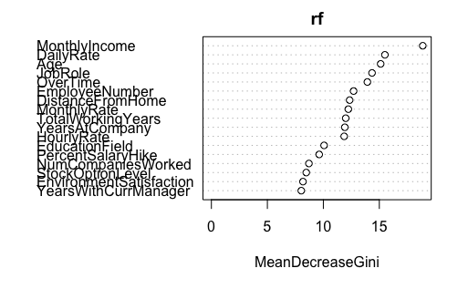

```r
plot1= varImpPlot(rf, n.var = 17)
```

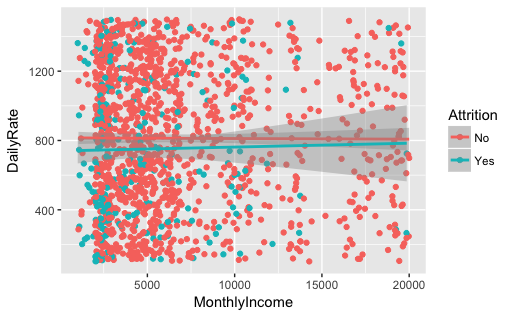

```r
df %>% ggplot(aes(MonthlyIncome, DailyRate, color = Attrition))+
  geom_point()+
  geom_smooth(method = "lm")
```

```r
df$Attrition = as.factor(df$Attrition)
```

[figure not shown]

```r
library(pdp)
rf %>%
  partial(pred.var = "DailyRate") %>%
  plotPartial(rug = TRUE, train = train, main = "Monthly Income Partial Dependence Plot")
```

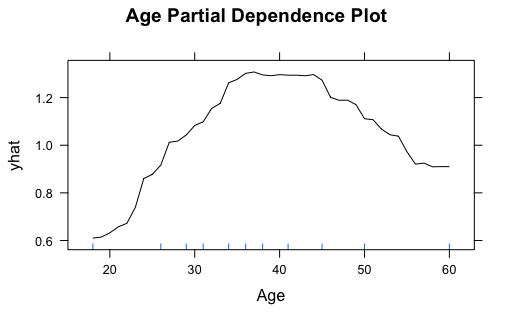

```r
library(pdp)
rf %>%
  partial(pred.var = "Age") %>%
  plotPartial(rug = TRUE, train = train, main = "Age Partial Dependence Plot")
```

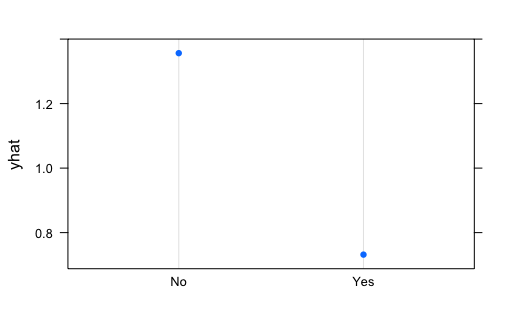

```r
library(pdp)
rf %>%
  partial(pred.var = "OverTime") %>%
  plotPartial(rug = TRUE, train = train)
```

```r
set.seed(2017)
ctrl <- trainControl(method = "repeatedcv", repeats = 3)
regFit <- train(
  Attrition ~ .,
  data = train %>% drop_na(),
  trControl = ctrl,
  method = "glm",
  #family = "binomial",
  ## Center and scale the predictors for the training
  ## set and all future samples.
  preProc = c("center", "scale"),
  tuneLength = 10
)
```

```r
pred = predict(regFit, test, type = "prob")
pred2 = predict(regFit, test)
prop.table(confusionMatrix(pred2, test$Attrition)$table)
```

```
          Reference
Prediction         No        Yes
       No  0.80227273 0.09090909
       Yes 0.03636364 0.07045455
```

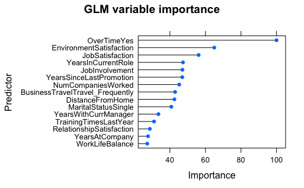

```r
plot(varImp(regFit),top = 15, main = "GLM variable importance", ylab = "Predictor")
```

```r
summary(regFit$finalModel)
```

[output not shown]

```r
Fit <- train(
  Attrition ~ .,
  data = train %>% drop_na(),
  trControl = ctrl,
  method = "rf",
  #family = "binomial",
  ## Center and scale the predictors for the training
  ## set and all future samples.
  preProc = c("center", "scale"),
  tuneLength = 10
)
```

```r
confusionMatrix(Fit)
```

```
Cross-Validated (10 fold, repeated 3 times) Confusion Matrix

(entries are percentual average cell counts across resamples)

          Reference
Prediction   No  Yes
       No  82.9 12.9
       Yes  1.0  3.2

 Accuracy (average) : 0.8605
```

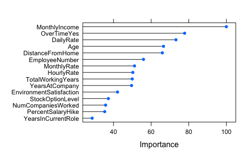

```r
plot(varImp(Fit), 15)
```

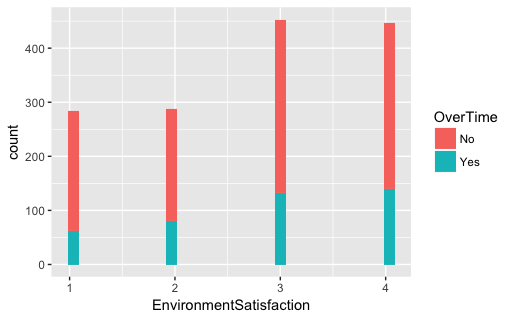

```r
df %>% ggplot(aes(EnvironmentSatisfaction, fill = OverTime))+
  geom_histogram(bins = 30)
```

```r
df %>% ggplot(aes(EmployeeSa, fill = OverTime))+
  geom_density()
```

[output not shown]